# Análisis Multivariado - Clase 8

2025-10-01

## Análisis Discriminante

## Motivación

\(X_1=\) Consumo de carne

\(X_2=\) Consumo de verduras

Dos grupos de personas \(A\) y \(B\)

- \(\mathbf{X}_A=(X_{1,A},X_{2,A})\sim N_2(\vec{\mu}_1,\mathbf{\Sigma}_1)\) \[\vec{\mu}_1=\begin{pmatrix} 80\\82 \end{pmatrix},\; \mathbf{\Sigma}_1 =\begin{pmatrix} 2.5 & 0\\0 & 3 \end{pmatrix} \]
- \(\mathbf{X}_B=(X_{1,B},X_{2,B})\sim N_2(\vec{\mu}_2,\mathbf{\Sigma}_2)\) \[\vec{\mu}_2=\begin{pmatrix} 75\\85 \end{pmatrix},\; \mathbf{\Sigma}_2 =\begin{pmatrix} 2 & 1.5\\1.5 & 2.5 \end{pmatrix} \]

## Objetivo

A partir del consumo de carne y verduras de una nueva persona, identificarla con uno de los grupos.

Para ello, tendríamos que poder dividir el espacio en 2:

- \(R_A=\) pares \((x_1,x_2)\) identificados con el grupo \(A\)
- \(R_B=\) pares \((x_1,x_2)\) identificados con el grupo \(B\)

## Máxima verosimilitud

Una forma de ver qué pares pertenecen a cada conjunto es elegir el grupo con mayor densidad conjunta de probabilidad.

**Ejemplo:** \(\mathbf{x}=(x_1,x_2)=(81,78)\)

- \(f_A(\mathbf{x})=\dfrac{1}{2\pi \cdot \sqrt{\frac{15}{2}}}\cdot e^{-\frac{1}{2}\cdot((81,78)-(80,82))\times \begin{pmatrix}\frac{2}{5}& 0\\0&\frac{1}{3} \end{pmatrix} \times ((81,78)-(80,82))^T }=\) \(=\dfrac{1}{\sqrt{30}\pi}\cdot e^{-\frac{43}{15}}\approx 0.00330607\)
- \(f_B(\mathbf{x})=\dfrac{1}{2\pi \cdot \sqrt{\frac{11}{4}}}\cdot e^{-\frac{1}{2}\cdot((81,78)-(75,85))\times \begin{pmatrix}\frac{10}{11}& -\frac{6}{11}\\-\frac{6}{11}&\frac{8}{11} \end{pmatrix} \times ((81,78)-(75,85))^T }\) \(=\dfrac{1}{\sqrt{11}\pi}\cdot e^{-\frac{628}{11}}\approx 1.541299\cdot 10^{-26}\)

Esta observación se identificaría con el grupo \(A\)

## Visualización

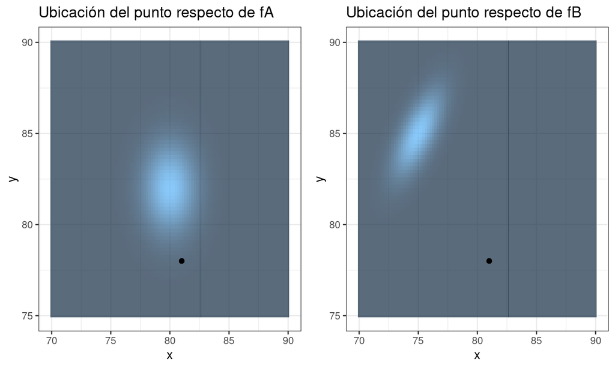

## Máxima verosimilitud

Una forma de ver qué pares pertenecen a cada conjunto es elegir el grupo con mayor densidad conjunta de probabilidad.

**Ejemplo:** \(\mathbf{x}=(x_1,x_2)=(74,80)\)

- \(f_A(\mathbf{x})=\dfrac{1}{2\pi \cdot \sqrt{\frac{15}{2}}}\cdot e^{-\frac{1}{2}\cdot((74,80)-(80,82))\times \begin{pmatrix}\frac{2}{5}& 0\\0&\frac{1}{3} \end{pmatrix} \times ((74,80)-(80,82))^T }=\) \(=\dfrac{1}{\sqrt{30}\pi}\cdot e^{-\frac{118}{15}}\approx 2.227612\cdot 10^{-5}\)
- \(f_B(\mathbf{x})=\dfrac{1}{2\pi \cdot \sqrt{\frac{11}{4}}}\cdot e^{-\frac{1}{2}\cdot((74,80)-(75,85))\times \begin{pmatrix}\frac{10}{11}& -\frac{6}{11}\\-\frac{6}{11}&\frac{8}{11} \end{pmatrix} \times ((74,80)-(75,85))^T }\) \(=\dfrac{1}{\sqrt{11}\pi}\cdot e^{-\frac{75}{11}}\approx 0.0001049675\)

Esta observación se identificaría con el grupo \(B\)

## Visualización

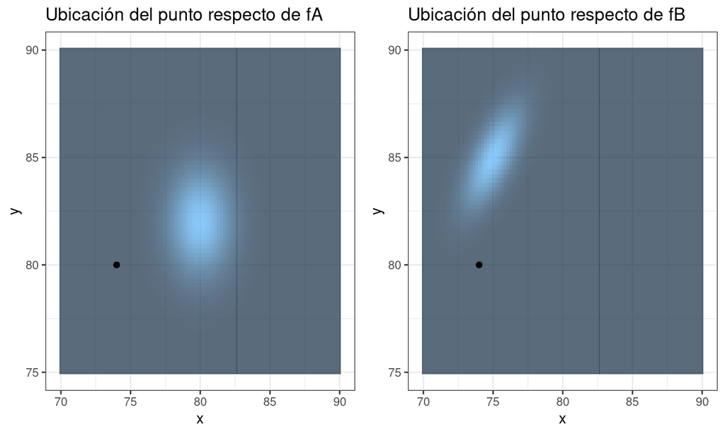

## Visualización 3D

[interactive chart not shown]

## Regla discriminante

Se llama regla discriminante a la partición del espacio que corresponde a cada punto con su clasificación correspondiente. En este caso, los conjuntos \(R_A\) y \(R_B\), que se pueden describir del siguiente modo:

- \(R_A=\{\mathbf{x}\in\mathbb{R}^2\,/\, f_A(\mathbf{x})>f_B(\mathbf{x})\}\)
- \(R_B=\{\mathbf{x}\in\mathbb{R}^2\,/\, f_A(\mathbf{x})<f_B(\mathbf{x})\}\)

## Representación gráfica

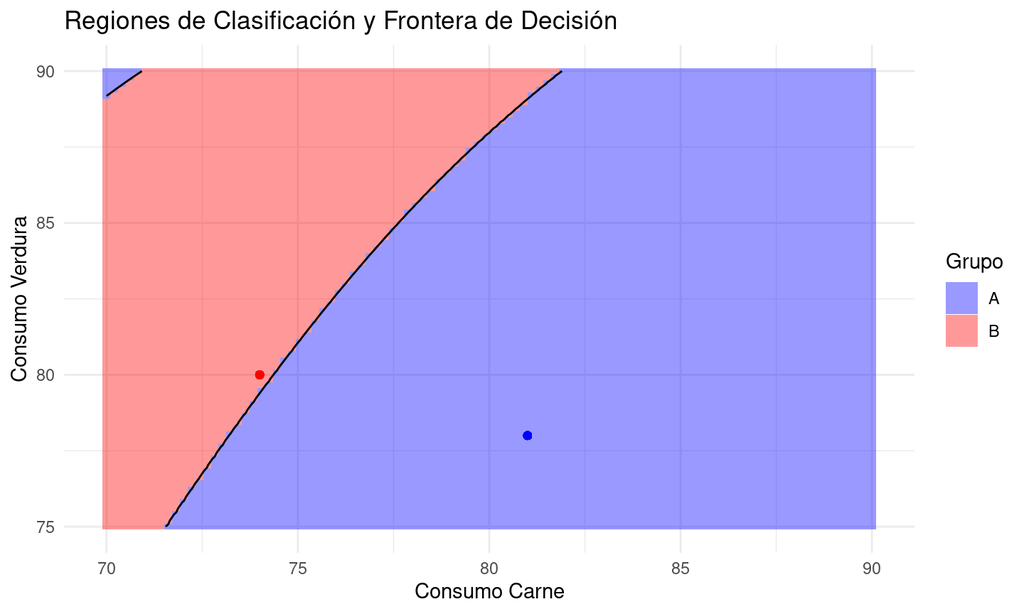

## Más grupos

Tres grupos de personas \(A\), \(B\) \(C\)

- \(\mathbf{X}_A=(X_{1,A},X_{2,A})\sim N_2(\vec{\mu}_1,\mathbf{\Sigma}_1)\) \[\vec{\mu}_1=\begin{pmatrix} 80\\82 \end{pmatrix},\; \mathbf{\Sigma}_1 =\begin{pmatrix} 2.5 & 0\\0 & 3 \end{pmatrix}\]
- \(\mathbf{X}_B=(X_{1,B},X_{2,B})\sim N_2(\vec{\mu}_2,\mathbf{\Sigma}_2)\) \[\vec{\mu}_2=\begin{pmatrix} 75\\85 \end{pmatrix},\; \mathbf{\Sigma}_2 =\begin{pmatrix} 2 & 1.5\\1.5 & 2.5 \end{pmatrix}\]
- \(\mathbf{X}_C=(X_{1,C},X_{2,C})\sim N_2(\vec{\mu}_3,\mathbf{\Sigma}_3)\) \[\vec{\mu}_3=\begin{pmatrix} 85\\85 \end{pmatrix},\; \mathbf{\Sigma}_2 =\begin{pmatrix} 2.5 & -1.5\\-1.5 & 2 \end{pmatrix}\]

## Máxima verosimilitud

Consideremos \(\mathbf{x}=(87,82)\)

- \(f_A(\mathbf{x})=\)

```
## [1] 3.222579e-06
```

- \(f_B(\mathbf{x})=\)

```
## [1] 4.039374e-40
```

- \(f_C(\mathbf{x})=\)

```
## [1] 0.009888283
```

En este caso, se identificaría el valor con la clase \(C\)

## Visualización

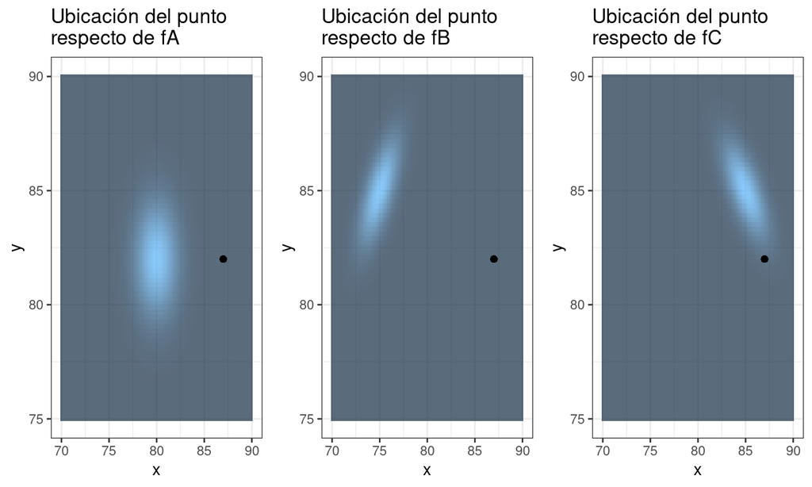

## Regla discriminante

En este caso, la regla discriminante cambia del siguiente modo:

- \(R_A=\{\mathbf{x}\in\mathbb{R}^2\,/\, f_A(\mathbf{x})>f_B(\mathbf{x}) \;\wedge\; f_A(\mathbf{x})>f_C(\mathbf{x}) \}\)
- \(R_B=\{\mathbf{x}\in\mathbb{R}^2\,/\, f_B(\mathbf{x})>f_A(\mathbf{x}) \;\wedge\; f_B(\mathbf{x})>f_C(\mathbf{x})\}\)
- \(R_C=\{\mathbf{x}\in\mathbb{R}^2\,/\, f_C(\mathbf{x})>f_A(\mathbf{x}) \;\wedge\; f_C(\mathbf{x})>f_B(\mathbf{x})\}\)

## Representación gráfica

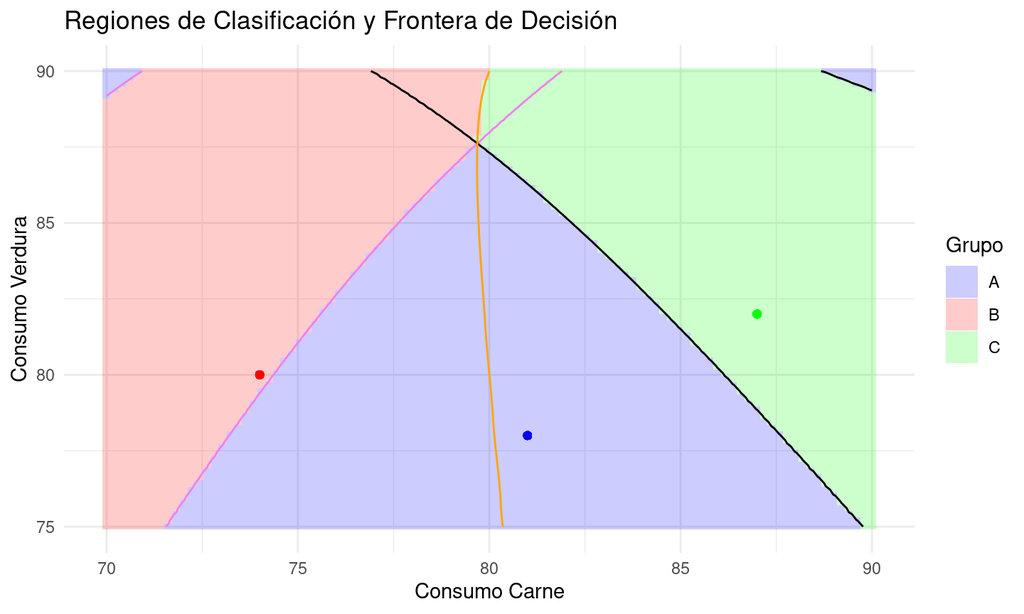

## Probabilidades a priori

Supongamos que originalmente se sabe que el grupo A tiene 100 personas, el grupo B tiene 200 personas y el grupo C tiene 300 personas. En este caso, si hay un empate en cuanto a la verosimilitud, tendría sentido optar por el grupo mayoritario.

Es decir, sabemos que:

- el grupo \(A\) tiene \(\frac{1}{6}\) del total
- el grupo \(B\) tiene \(\frac{1}{3}\) del total
- el grupo \(C\) tiene \(\frac{1}{2}\) del total

Por lo tanto, le daremos ese peso también a la verosimilitud.

## Regla Discriminante Bayesiana

Tomando las probabilidades a priori \(\pi_A=\frac{1}{6}\), \(\pi_B=\frac{1}{3}\) y \(\pi_C=\frac{1}{2}\), se decide la siguiente regla discriminante:

- \(R_A=\{\mathbf{x}\in\mathbb{R}^2\,/\, \pi_A\cdot f_A(\mathbf{x})>\pi_B\cdot f_B(\mathbf{x}) \;\wedge\; \pi_A\cdot f_A(\mathbf{x})>\pi_C\cdot f_C(\mathbf{x}) \}\)
- \(R_B=\{\mathbf{x}\in\mathbb{R}^2\,/\, \pi_B\cdot f_B(\mathbf{x})> \pi_A\cdot f_A(\mathbf{x}) \;\wedge\; \pi_B\cdot f_B(\mathbf{x})> \pi_C\cdot f_C(\mathbf{x})\}\)
- \(R_C=\{\mathbf{x}\in\mathbb{R}^2\,/\, \pi_C\cdot f_C(\mathbf{x})> \pi_A\cdot f_A(\mathbf{x}) \;\wedge\; \pi_C\cdot f_C(\mathbf{x})>\pi_B\cdot f_B(\mathbf{x})\}\)

## Representación Gráfica

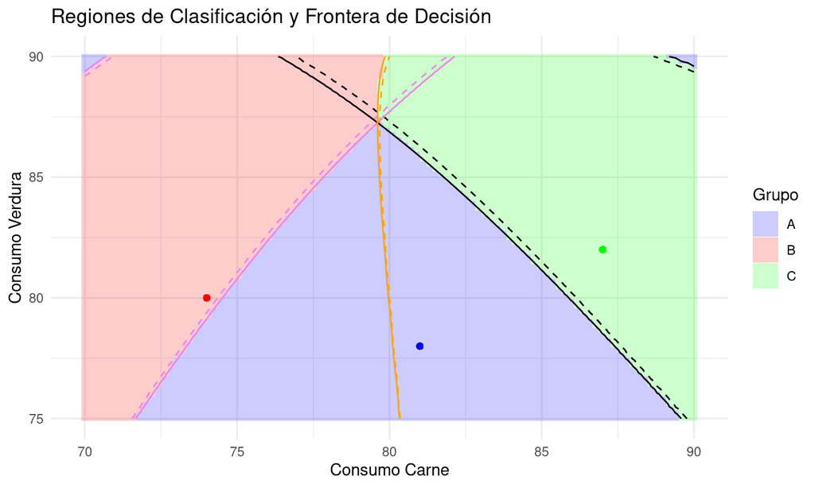

## Datos Reales

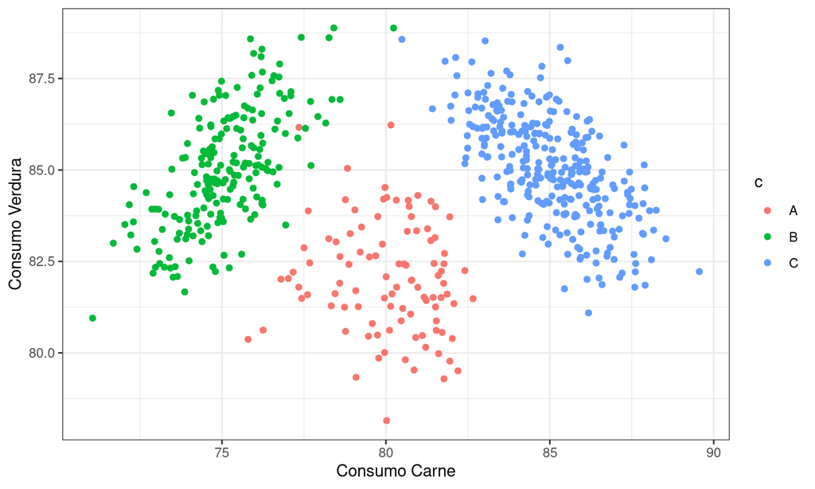

## Estimaciones

Cuando se tienen datos que no saben qué distribución normal multivariada tienen, se tienen que estimar sus vectores de medias, sus matrices de covarianza y sus probabilidades a priori:

- \(\vec{\mu}_A,\,\vec{\mu}_B,\,\vec{\mu}_C \mapsto \overline{\mathbf{x}}_A=\dfrac{\sum_{\mathbf{x}_i \in A} \mathbf{x}_i}{n_A},\,\overline{\mathbf{x}}_B=\dfrac{\sum_{\mathbf{x}_i \in B} \mathbf{x}_i}{n_B},\,\overline{\mathbf{x}}_C=\dfrac{\sum_{\mathbf{x}_i \in C} \mathbf{x}_i}{n_C}\)
- \(\mathbf{\Sigma}_A,\,\mathbf{\Sigma}_B,\,\mathbf{\Sigma}_C \mapsto\) \(\mathbf{S}_A=\dfrac{\sum_{\mathbf{x}_i \in A} (\mathbf{x}_i-\overline{\mathbf{x}}_A)^T\times (\mathbf{x}_i-\overline{\mathbf{x}}_A)}{n_A-1}\) \(\mathbf{S}_B=\dfrac{\sum_{\mathbf{x}_i \in A} (\mathbf{x}_i-\overline{\mathbf{x}}_B)^T\times (\mathbf{x}_i-\overline{\mathbf{x}}_B)}{n_B-1}\) \(\mathbf{S}_C=\dfrac{\sum_{\mathbf{x}_i \in A} (\mathbf{x}_i-\overline{\mathbf{x}}_A)^T\times (\mathbf{x}_i-\overline{\mathbf{x}}_C)}{n_C-1}\)
- \(\pi_A,\,\pi_B,\,\pi_C \mapsto \widehat{p}_A=\dfrac{n_A}{n},\,\widehat{p}_B=\dfrac{n_B}{n},\,\widehat{p}_C=\dfrac{n_C}{n}\)

## QDA

Tomando las mismas decisiones con estas estimaciones se obtiene el algoritmo llamado Quadratic Discriminant Analysis.

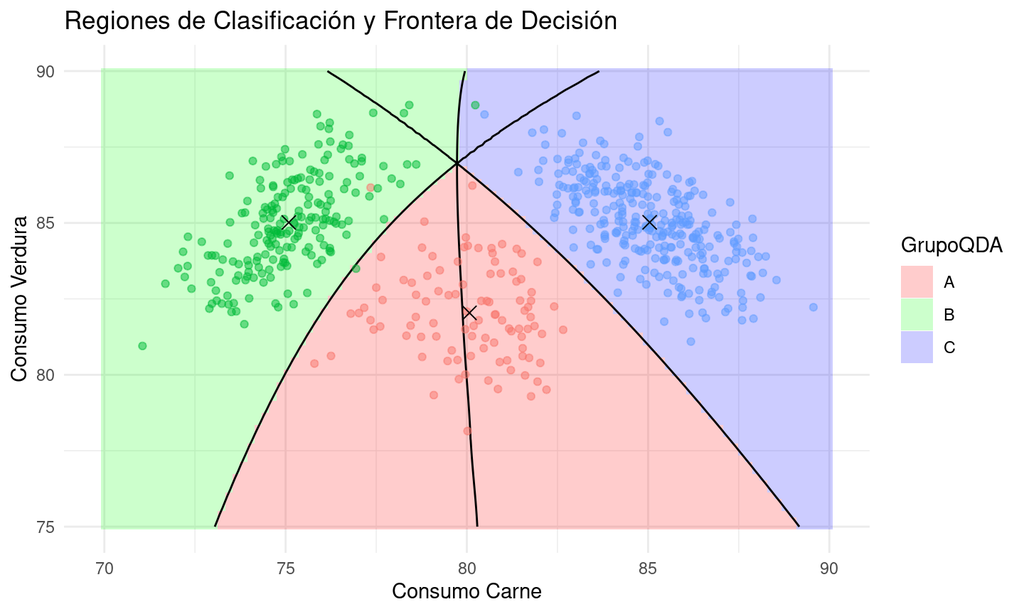

## QDA

Vemos que el output de QDA considera distintas formas de escalar los datos para cada grupo:

```
## , , A
##
##           1          2
## x 0.6550627 0.08379575
## y 0.0000000 0.65944002
##
## , , B
##
##           1          2
## x 0.7121652 -0.6045315
## y 0.0000000  0.8180358
##
## , , C
##
##            1          2
## x -0.6520019 -0.5341110
## y  0.0000000 -0.8979273
```

## LDA

El algoritmo de Linear Discriminant Analysis asume que las matrices de covarianza en todos los grupos es la misma, simplificando algunos cálculos, pero resulta justamente en divisiones lineales en la regla discriminante

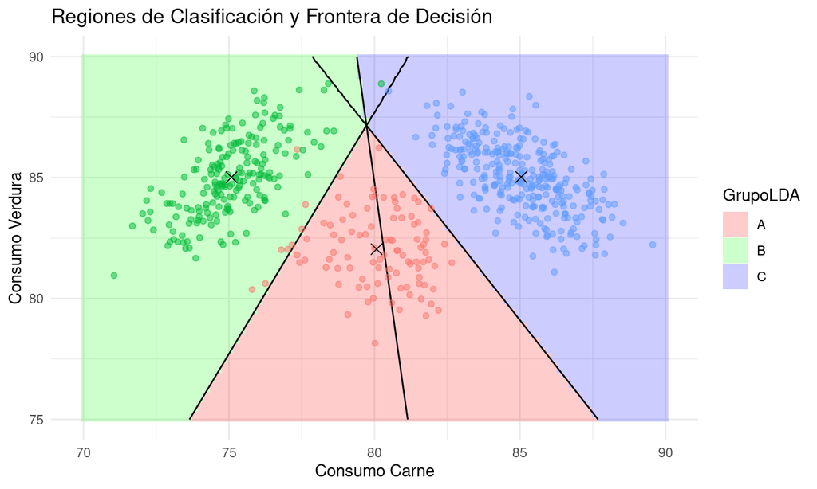

## LDA

Vemos que el output de LDA considera una sola forma de escalar los datos, por lo que no hace diferencia por grupos:

```r
lda_model$means
```

```
##          x        y
## A 80.07202 82.03926
## B 75.08809 85.01502
## C 85.04289 85.02097
```

```r
lda_model$scaling
```

```
##           LD1        LD2
## x -0.67525674 -0.0197325
## y -0.09749045  0.6593146
```

## Naive Bayes

Hay otro algoritmo de clasificación que se denomina Naive Bayes, que asume que las distribuciones en cada clase son normales multivariadas, pero sin correlación entre las variables. Es decir, las matrices de covarianza serían matrices diagonales.

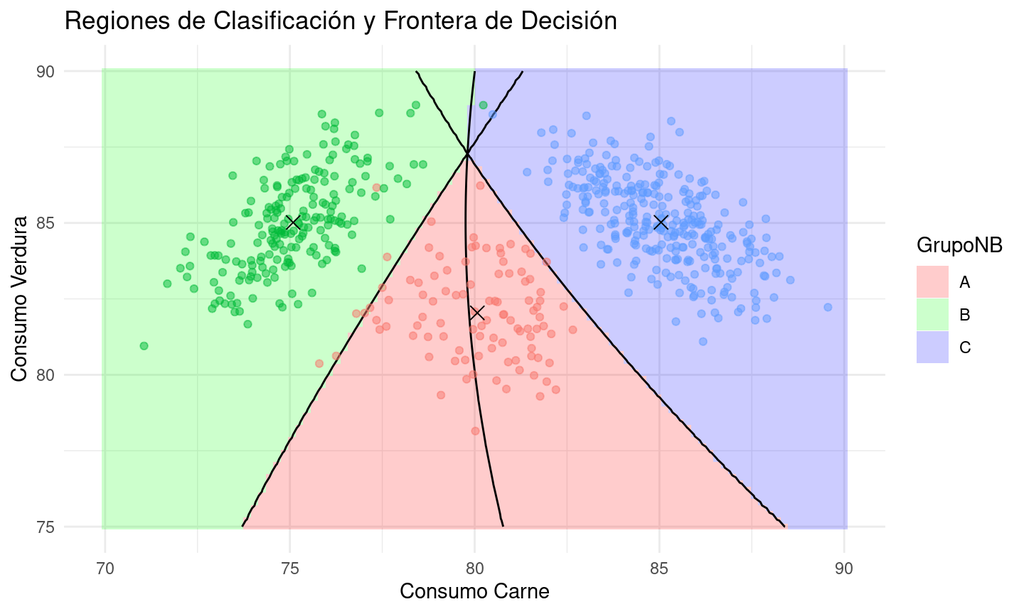

## Naive Bayes

El output de naive bayes, sólo muestra las medias y desvíos por variable en cada grupo (dado que las matrices son diagonales, no hace falta más información):

```
## $x
##    x
## Y       [,1]     [,2]
##   A 80.07202 1.526571
##   B 75.08809 1.404169
##   C 85.04289 1.533738
##
## $y
##    y
## Y       [,1]     [,2]
##   A 82.03926 1.528795
##   B 85.01502 1.603481
##   C 85.02097 1.439646
```

## Datos superpuestos

En el caso anterior, veíamos que todos los algoritmos funcionaban de manera similar. Sin embargo, esto se debía a que las restricciones en las matrices de covarianza se terminaban compensando por las medias calculadas. En el siguiente ejemplo, se debería notar más claramente la diferencia entre los algoritmos.

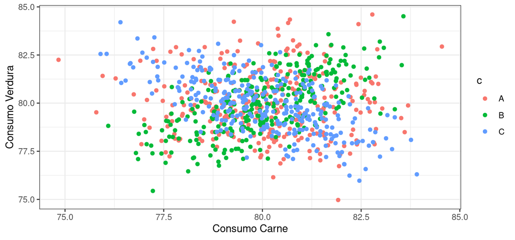

## Naive Bayes

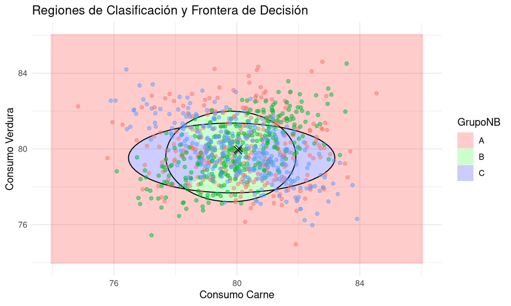

## LDA

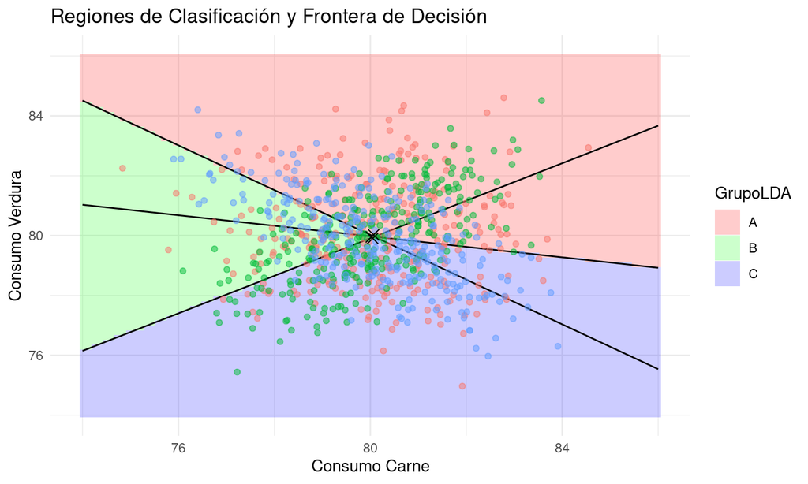

## QDA

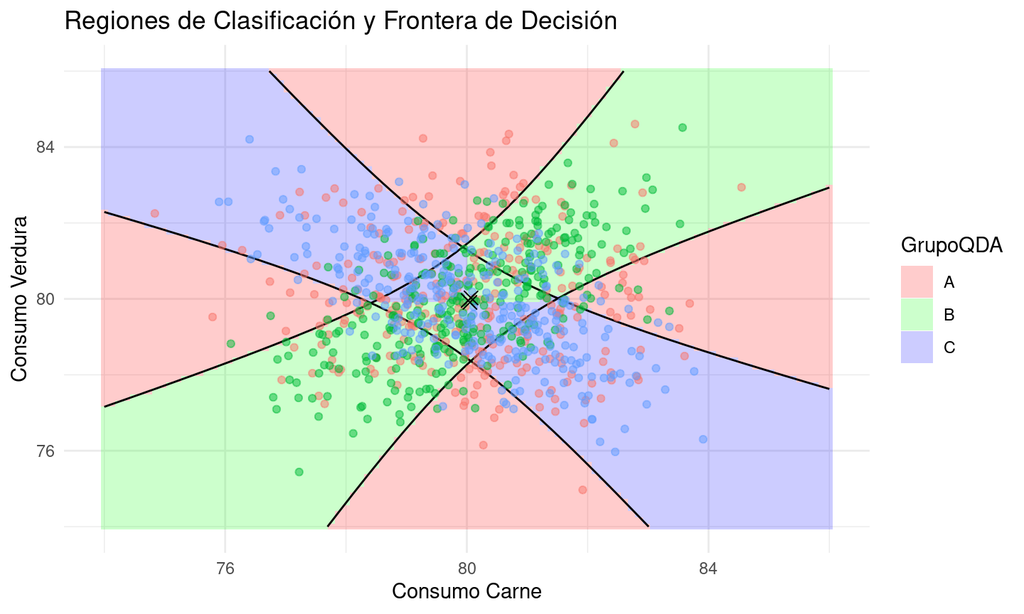